# 시각화를 통한 데이터 탐색

올림푸스

2020-03-31

# 데이터 탐색 시각화

## 고객의 성별/연령별 분포

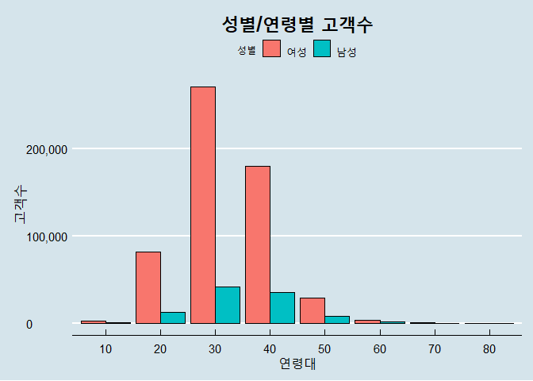

## 대분류별 매출액 및 판매 건수 TOP 10

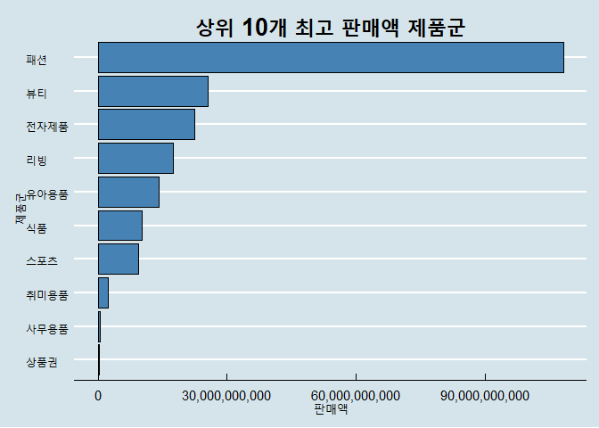

```r
aa <- ggplot(data=top_buy, aes(reorder(CN_Name, sum, identity), sum))
aa + geom_col(fill = 'steelblue', col='black') +
  labs(title = "상위 10개 최고 판매액 제품군", x = "제품군", y = "판매액") +
  scale_fill_discrete(name = "제품군") +
  coord_flip() + scale_color_economist() + theme_economist() +
  theme(plot.title = element_text(face = "bold", hjust = 0.5, size = 20, color = "black")) +
  theme(axis.title = element_text(size = 12, color = "black")) +
  scale_y_continuous(labels = scales::comma)
```

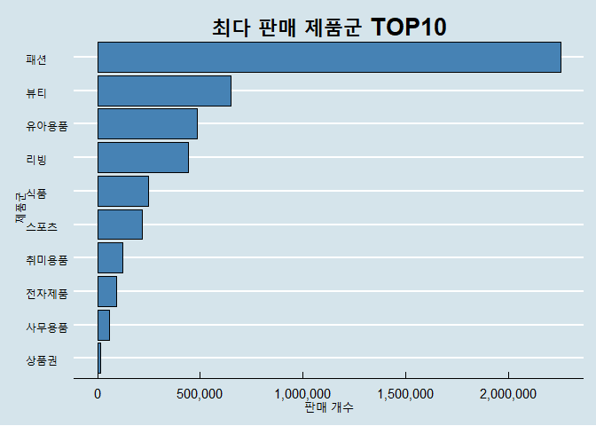

```r
## 대분류별 판매건수 TOP 10

# 대대분류 판매 개수 top10
top_ct <- df_all %>%
  group_by(CN_Name) %>%
  summarise(sum=sum(PD_BUY_CT)) %>%
  arrange(-sum) %>%
  head(10)

bb <- ggplot(data=top_ct, aes(reorder(CN_Name, sum, identity), sum))
bb + geom_col(fill = 'steelblue',col='black') +
  labs(title = "최다 판매 제품군 TOP10", x = "제품군", y = "판매 개수") +
  scale_fill_discrete(name = "제품군") +
  coord_flip()  + scale_color_economist() + theme_economist() +
  theme(plot.title = element_text(face = "bold", hjust = 0.5, size = 20, color = "black")) +
  theme(axis.title = element_text(size = 12, color = "black")) +
  scale_y_continuous(labels = scales::comma)
```

### *인사이트* - 매출액이 패션에 크게 치중되어 있다. - 전자제품의 경우, 매출액은 높지만 판매 건수는 상대적으로 낮다 - 유아용품의 경우, 매출액은 낮지만 판매 건수는 상대적으로 많다

## 연령대별 전체 고객 최고 판매액 제품군

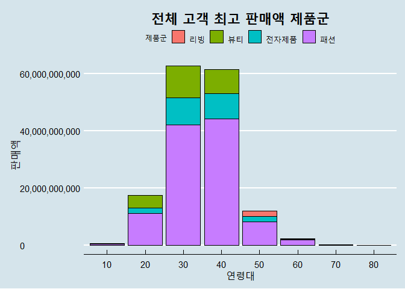

```r
temp <- df_all %>%
  group_by(CLNT_AGE, CN_Name) %>%
  summarise(판매액=sum(PD_BUY_TOT)) %>%
  arrange(CLNT_AGE, -판매액) %>%
  mutate(rank=row_number()) %>%
  filter(rank %in% c(1,2,3))

ggplot(temp, aes(x = CLNT_AGE, y = 판매액, fill = CN_Name)) +
  geom_bar(stat = "identity",col='black') +
  labs(title = "전체 고객 최고 판매액 제품군", x = "연령대", y = "판매액") +
  scale_fill_discrete(name = "제품군") + scale_color_economist() + theme_economist() +
  theme(plot.title = element_text(face = "bold", hjust = 0.5, size = 20, color = "black")) +
  theme(axis.title = element_text(size = 16, color = "black")) +
  scale_y_continuous(labels = scales::comma)
```

## 연령대별 여성 고객 최고 판매액 제품군

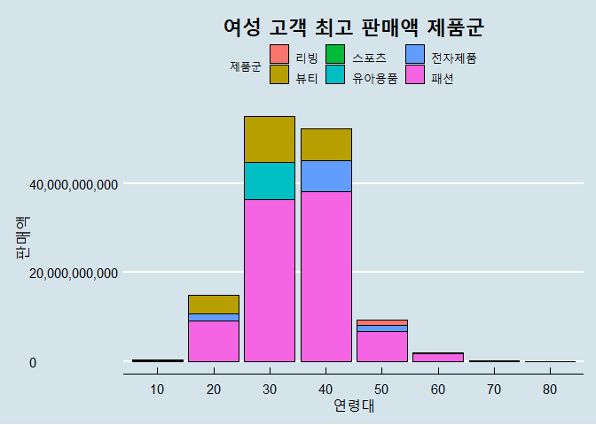

```r
temp_f <- df_all %>%
  group_by(CLNT_AGE, CLNT_GEN, CN_Name) %>%
  summarise(판매액=sum(PD_BUY_TOT)) %>%
  arrange(CLNT_AGE, -판매액) %>%
  mutate(rank=row_number()) %>%
  filter(rank %in% c(1,2,3)) %>%
  filter(CLNT_GEN == "F")

ggplot(data = temp_f) +
  geom_bar(mapping = aes(x = CLNT_AGE, y = 판매액, fill = CN_Name),
           stat = "identity", position = 'stack', col='black') +
  labs(title = "여성 고객 최고 판매액 제품군", x = "연령대", y = "판매액") +
  scale_fill_discrete(name = "제품군") + scale_color_economist() + theme_economist() +
  theme(plot.title = element_text(face = "bold", hjust = 0.5, size = 20, color = "black")) +
  theme(axis.title = element_text(size = 16, color = "black")) +
  scale_y_continuous(labels = scales::comma)
```

## 연령대별 남성 고객 최고 판매액 제품군

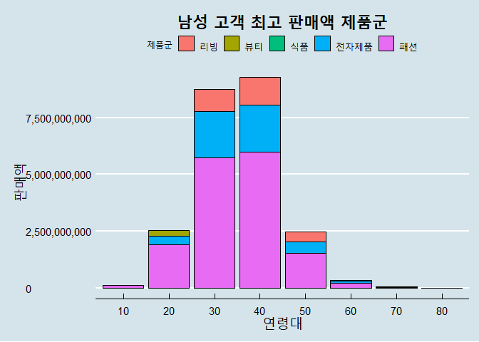

```r
temp_m <- df_all %>%
  group_by(CLNT_AGE, CLNT_GEN, CN_Name) %>%
  summarise(판매액=sum(PD_BUY_TOT)) %>%
  arrange(CLNT_AGE, -판매액) %>%
  mutate(rank=row_number()) %>%
  filter(rank %in% c(1,2,3)) %>%
  filter(CLNT_GEN == "M")

ggplot(data = temp_m) +
  geom_bar(mapping = aes(x = CLNT_AGE, y = 판매액, fill = CN_Name),
           stat = "identity", position = 'stack', col='black') +
  labs(title = "남성 고객 최고 판매액 제품군", x = "연령대", y = "판매액") +
  scale_fill_discrete(name = "제품군") + scale_color_economist() + theme_economist() +
  theme(plot.title = element_text(face = "bold", hjust = 0.5, size = 20, color = "black")) +
  theme(axis.title = element_text(size = 18, color = "black")) +
  scale_y_continuous(labels = scales::comma)
```

### *인사이트*

- 전체 및 남성 30대 고객과 비교했을 때, 30대 여성의 유아용품 구매가격이 눈에 띈다

#### * 전체적으로 패션 카테고리의 판매액이 도드라진다. 그렇다면, 판매액이 높은 고객들을 VIP로 구분해 클러스터링을 진행한 결과는 어떻게 될까?

## 데이터 설명

`vip_train`은 구매 데이터에서 구매액 기준 박스플롯에서 최댓값 이상의 고객을 VIP로 규정해 담은 데이터 프레임이다. `vip_train$class`에는 군집화 한 결과가 1과 2로 구분되어져있다:

| CLNT_ID | CLNT_GEN | CLNT_AGE | class |
| --- | --- | --- | --- |
| 5851409 | F | 30 | 2 |
| 5860385 | F | 40 | 2 |
| 5977726 | M | 30 | 1 |
| 2167514 | F | 30 | 1 |
| 4848283 | F | 40 | 2 |

## 데이터 정제

레이더 차트 함수 `raiderchart{fmsb}`에 맞는 데이터 프레임 구조를 만들기 위해 `vip_train`을 다음과 같이 정제했다:

```r
radar <- vip_train %>%
  group_by(class) %>%
  summarise(
      전자제품 = sum(C1_CT),
      리빙 = sum(C2_CT),
      식품 = sum(C3_CT),
      스포츠 = sum(C4_CT),
      패션 = sum(C5_CT),
      뷰티 = sum(C6_CT),
      유아용품 = sum(C7_CT),
      취미용품 = sum(C8_CT),
      사무용품 = sum(C9_CT),
      상품권 = sum(C10_CT) )
radar = as.data.frame(radar)
radar <- radar[-1]
knitr::kable(head(radar,5))
```

| 전자제품 | 리빙 | 식품 | 스포츠 | 패션 | 뷰티 | 유아용품 | 취미용품 | 사무용품 | 상품권 |
| --- | --- | --- | --- | --- | --- | --- | --- | --- | --- |
| 2485 | 3314 | 2919 | 4115 | 78418 | 8674 | 4874 | 626 | 339 | 73 |
| 11332 | 15602 | 11096 | 7481 | 24709 | 19856 | 14382 | 2920 | 973 | 142 |

추가로, 구매 개수의 최소/최댓값을 데이터 프레임에 추가해 주어야 한다.

```r
range(radar)
```

[1] 73 78418

```r
radarC <- rbind(rep(78418,10), rep(73, 10), radar )
rownames(radarC) <- c('최댓값','최솟값','cluster 1','cluster 2')
knitr::kable(head(radarC, 5))
```

|  | 전자제품 | 리빙 | 식품 | 스포츠 | 패션 | 뷰티 | 유아용품 | 취미용품 | 사무용품 | 상품권 |
| --- | --- | --- | --- | --- | --- | --- | --- | --- | --- | --- |
| 최댓값 | 78418 | 78418 | 78418 | 78418 | 78418 | 78418 | 78418 | 78418 | 78418 | 78418 |
| 최솟값 | 73 | 73 | 73 | 73 | 73 | 73 | 73 | 73 | 73 | 73 |
| cluster 1 | 2485 | 3314 | 2919 | 4115 | 78418 | 8674 | 4874 | 626 | 339 | 73 |
| cluster 2 | 11332 | 15602 | 11096 | 7481 | 24709 | 19856 | 14382 | 2920 | 973 | 142 |

## 결과

정제한 데이터 프레임을 단순히 `raiderchart()`에 넣었을때 다음과 같은 차트가 나온다:

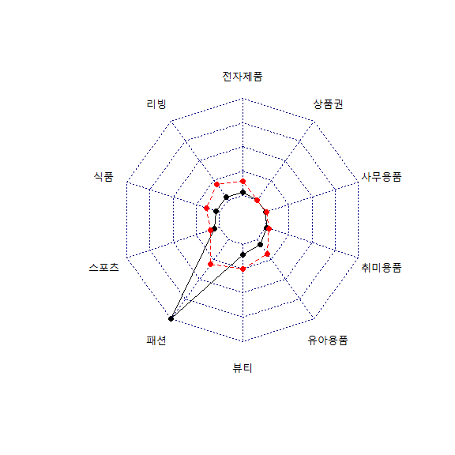

```r
radarchart(radarC)
```

보기 쉽게 여러 인자를 추가할 경우 다음과 같은 결과가 나온다:

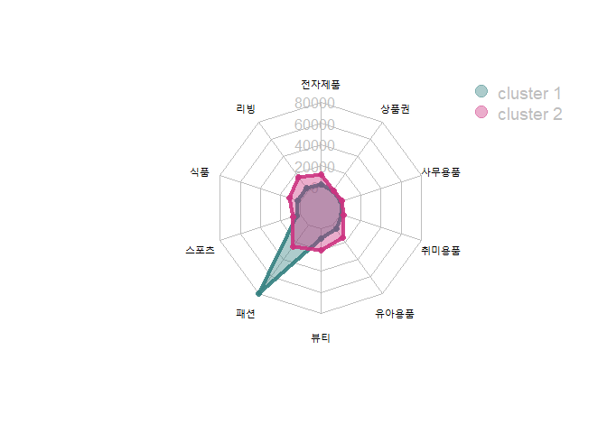

```r
# 색 설정
colors_border=c( rgb(0.2,0.5,0.5,0.9), rgb(0.8,0.2,0.5,0.9) , rgb(0.7,0.5,0.1,0.9) )
colors_in=c( rgb(0.2,0.5,0.5,0.4), rgb(0.8,0.2,0.5,0.4) , rgb(0.7,0.5,0.1,0.4) )

# 레이더 차트 생성
radarchart( radarC  , axistype=1 ,
                 #custom polygon
                   pcol=colors_border , pfcol=colors_in , plwd=4 , plty=1,
                 #custom the grid
                   cglcol="grey", cglty=1, axislabcol="grey", caxislabels=seq(0,80000,20000), cglwd=0.8,
                 #custom labels
                   vlcex=0.8
               )
               # caxislabels=seq(0,80000,20000) : 중앙부터 8만까지 2만의 단위로 선을 긋는다

# 범주(legend) 생성
 legend(x='topright', y=1, legend = rownames(radarC[c(3,4),]), bty = "n", pch=20 ,
                 col=colors_in , text.col = "grey", cex=1.2, pt.cex=3)
```

### *인사이트*

- `vip_train`에서 클러스터링 된 그룹 `cluster 1`은 패션에 치우친 구매 패턴을 보인다.
- `cluster 2`는 상품권, 사무용품, 취미용품을 제외한 전 분야에서 고르게 구매를 하는 패턴을 보인다.